# Weekly Economic Update

### **What’s new this week?**

- **The Canadian economy contracted in the third quarter by 0.3 per cent:** Canada’s economy shrank in the three months up to September, as household spending was flat and exports declined.
- The economy added **25,000 jobs in November, while the unemployment rate rose 0.1% to 5.8%**, the highest since January 2022.
- Canada’s November **small business optimism 3-month index fell by 3.4** points to 37.7, while the 12-month index declined by 1.5 points to 45.6.

### **Chart of the week: Inflation continues to be sticky**

[interactive chart not shown]

```r
setwd("S:/ERPA Correspondence/Weekly economic update/Current Updates/549 February 23, 2024")
getwd()
```

```
## [1] "S:/ERPA Correspondence/Weekly economic update/Current Updates/549 February 23, 2024"
```

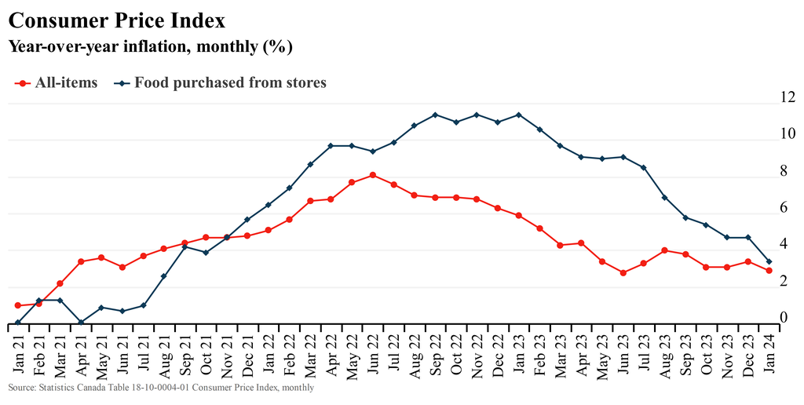

```r
#UPLOAD GRAPHS for Women +
#Save the Highcharts graph as an HTML file
saveWidget(WEU_01_19_1, file = "Chart02_20.html")
# Take a screenshot of the Highcharts graph and save it as an image file
webshot("Chart02_20.html", "Chart02_20.png", delay = 1, zoom = 4, vheight = 500)
```

### **Canadian economic indicators**

- Canada’s third quarter GDP contracted by 0.3% driven by a 25.4% drop in refined petroleum exports and 18.5% drop in investment in inventories. Higher housing investments (+2.0%) and flat household spending partially offset these losses.
- Real GDP edged up 0.1% in September driven by the goods-producing industries (+0.3%) while the services-producing industries remained essentially unchanged. Advance information indicates that real GDP increased by 0.2% in October, as increases in mining, quarrying, and oil and gas extraction, retail trade, and construction were only partially offset by decreases in wholesale trade.
- The unemployment rate rose by 0.1 percentage points to 5.8%, continuing its upward trend since April. The employment rate fell by 0.1 percentage points to 61.8% in November, as the growth of the population continued to outpace employment growth.
- On a year-over-year basis, average hourly wages (not seasonally adjusted) rose by 4.8% (or $1.57) to $34.28 in November, following a similar increase in October (+4.8%).
- Job vacancies dropped by 6.1% to 632,000 and average weekly earnings remained unchanged at $1,219. At the sector level, the largest decline in vacancies was observed in accommodation and food services (-15,000; -18.8%), construction (-10,800; -17.3%), finance and insurance (-9,800; -39.2%), and public administration (-2,400; -14.8%).
- In November, small business optimism fell 3.4 points to 37.7 for the next 3-months, and fell 1.5 points to 45.6 for the next 12-months. Nearly half of businesses stated that insufficient domestic demand was constraining sales, and taxes and wages were cited among the top input cost constraints.

### **U.S. economic news**

- US real GDP increased at an annual rate of 5.2% in the third quarter of 2023 according to the “second” estimate, well above the 2.1% gain realized in the previous quarter and the fastest pace on record since the fourth quarter of 2021.
- The advance figure for seasonally adjusted initial claims for unemployment insurance was 218,000 during the week ending November 25, up 7,000 from the previous week’s revised level.

### **Economic reports**

##### **1) Self-employment among women in Canada**

- [A recent Statistics Canada study](https://www150.statcan.gc.ca/n1/pub/75-006-x/2023001/article/00014-eng.pdf) examined self-employment among women—including its growth, occupations, and the differences among women with different characteristics—found that **a growing share of women are becoming self-employed. In 2022, 37% of all self-employed individuals were women, up from 26% in 1976. Despite this growth, women remain less likely to be in self-employment than men. In 2022, 11% of employed women were self-employed, compared to 16% for employed men.**
- This study also shows evidence on **persisting gender-specific labour market segregation.** In 2022, self-employed women were shown to be overrepresented in female-dominated occupations, such as being childcare providers. By contrast, in the same year, self-employed men were reported to be mostly working in historically male-dominated occupations, such as home building and renovation managers. Self-employed men were also reported to worked as managers in agriculture and as transport truck drivers more often than women.
- **Self-employment among women also differed by age.** In 2022, 2% of young women (aged 15 to 24 years) in the labour force were self-employed, down from 5% in 1976. By contrast, the self-employment rate among older women (aged 55 years and over) increased from 14% to 18% over the same period. With respect to various groups, self-employment varied little among Indigenous women (9%), racialized women (10%) and non-racialized, non-Indigenous women (12%). However, there are differences within the racialized groups and Indigenous women. Among racialized groups, Korean women are most likely to be self-employed, with one in five (20%) in self-employment, while Filipino women (5%) and Black women (6%) are least likely. With respect to Indigenous women, self-employment rate among women stood at 7% for First Nations people living off reserve, 10% for Métis women, and 4% for Inuit women.

### **Summary of economic indicators**

| **Monthly** | **Nov-23** | **Oct-23** | **Sept-23** | **Aug-23** | **Jul-23** |
| --- | --- | --- | --- | --- | --- |
| GDP growth, basic price (%) | N.A. | N.A. | 0.1 | 0.0 | 0.0 |
| Employment growth (%) | 0.1 | 0.1 | 0.3 | 0.2 | 0.0 |
| Unemployment rate (%) | 5.8 | 5.7 | 5.5 | 5.5 | 5.5 |
| Inflation (%, YoY) | N.A. | 3.1 | 3.8 | 4.0 | 3.3 |
| **Quarterly** | **2023 Q3** | **2023 Q2** | **2023 Q1** | **2022 Q4** | **2022 Q3** |
| GDP at market price (%, QoQ) | -0.3 | 0.0 | 0.6 | 0.0 | 0.9 |
| Labour productivity (%, QoQ) | N.A. | -0.6 | -0.8 | -0.4 | -0.4 |
| GDP at market price (%, YoY) | 0.7 | 1.1 | 2.1 | 2.1 | 3.8 |
| Labour productivity (%, YoY) | N.A. | -2.2 | -2.0 | -1.1 | -1.1 |

### **Summary of financial indicators**

|  | Level at around 4PM ET, Thursday | Change since last week close | Change since end of last month close | Change since beginning of 2023 | Change since beginning of 2022 |  |
| --- | --- | --- | --- | --- | --- | --- |
| **Market Index** |  |  |  |  |  |  |
| TSX | 20,210.07 | 0.5% | 7.1% | 1.2% | -5.3% |  |
| S&P 500 | 4,559.66 | 0.1% | 8.7% | 18.3% | -4.9% |  |
| Dow Jones | 35,979.25 | 2.0% | 8.9% | 8.5% | -0.9% |  |
| FTSE 100 | 7,482.97 | 0.0% | 0.0% | 2.2% | -0.3% |  |
| Nikkei 225 | 33,431.51 | -0.1% | 8.3% | 26.1% | 14.9% |  |
| NASDAQ | 14,161.28 | -0.7% | 10.2% | 35.2% | -10.0% |  |
| DAX | 16,293.55 | 1.9% | 10.0% | 17.1% | 1.7% |  |
| **Bond yield** |  |  |  |  |  |  |
| 3 month (CA) | 4.99% | -0.05pp | -0.04pp | 0.93pp | 4.79pp |  |
| 3 month (US) | 5.39% | 0.00pp | -0.10pp | 1.03pp | 5.29pp |  |
| 10 years (CA) | 3.56% | -0.13pp | -0.49pp | 0.60pp | 1.97pp |  |
| 10 years (US) | 4.34% | -0.07pp | -0.59pp | 0.73pp | 2.83pp |  |
| **Commodity Benchmark (USD)** |  |  |  |  |  |  |
| West Texas Intermediate | USD 76.04 | -0.41% | -5.47% | -5.60% | -4.30% |  |
| Brent | USD 80.73 | -0.85% | -4.61% | -7.17% | 2.22% |  |
| Western Canadian Select | USD 50.96 | -3.43% | -8.33% | -14.06% | -22.49% |  |
| Gold (oz) | USD 2,040.28 | 2.38% | 3.13% | 15.39% | 13.27% |  |